# **{tidymodels}를 이용한 보상 보험금 청구액 예측**

## **0 Before start**

이 자료는 [제 깃허브 저장소](https://github.com/be-favorite/Kaggle-ActuarialLossPrediction)로부터 제공됩니다. 대회 및 자료에 대한 자세한 사항은 저장소 메인의 README.md를 참고해주세요.😊

## **1 Preparing**

### 1.1 패키지 불러오기

```r
library(tidymodels)
```

```r
library(vroom)
library(corrplot)
ggplot2::theme_set(theme_light())
loaded_package <- c("vroom", "corrplot")
.version <- map(loaded_package, packageVersion)
names(.version) <- loaded_package
.version
```

```
## $vroom
## [1] '1.3.2'
##
## $corrplot
## [1] '0.84'
```

### 1.2 자료 불러오기

```r
claim_train <- vroom("./data/train.csv")
```

```r
claim_test <- vroom("./data/test.csv")
```

분석에 이용할 자료는 훈련 자료(training data, $n = 54,000$), 시험 자료(test data, $n = 36,000$)를 합쳐 총 90,000명의 근로자의 보상 보험에 대한 정보를 담고있다. 각 변수에 대한 자세한 설명은 다음과 같다:

- ClaimNumber: 고유 청구 번호
- DataTimeOfAccident: 사고 발생 날짜 및 시간
- DateReported: 사고가 보고된 날짜
- Age: 근로자의 나이
- Gender: 근로자의 성별
- MaritalStatus: 근로자의 결혼여부
  - (M)arried: 기혼
  - (S)ingle: 미혼
  - (U)nkown: 알 수 없음
- DependentChildren: 부양 자녀의 수
- DependentsOther: 자녀 외 부양 가족의 수
- WeeklyWages: 주급
- PartTimeFullTime: 파트타임, 풀타임 여부를 나타내는 이진형 변수
  - (P): 파트타임
  - (F): 풀타임
- HoursWorkedPerWeek: 주당 노동 시간
- DaysWorkedPerWeek: 주당 노동 일 수
- ClaimDescription: 보상 청구에 관한 설명
- IntiallncurredClaimCost: 보험업자가 추정한 초기 청구비용
- UltimateIncurredClaimCost($y$): 보험 회사가 지급한 총 보험금. 즉, 우리가 시험자료에 대한 예측이 필요한 부분

## **2 EDA**

이제 모델링 작업에 앞서 EDA 작업을 수행한다. 먼저, 훈련자료와 시험자료를 결합해준다.

```r
claim <- bind_rows(claim_train, claim_test) %>%
  rowid_to_column
glimpse(claim)
```

```
## Rows: 90,000
## Columns: 16
## $ rowid                     <int> 1, 2, 3, 4, 5, 6, 7, 8, 9, 10, 11, 12, 13...
## $ ClaimNumber               <chr> "WC8285054", "WC6982224", "WC5481426", "W...
## $ DateTimeOfAccident        <dttm> 2002-04-09 07:00:00, 1999-01-07 11:00:00...
## $ DateReported              <dttm> 2002-07-05, 1999-01-20, 1996-04-14, 2005...
## $ Age                       <dbl> 48, 43, 30, 41, 36, 50, 39, 56, 49, 30, 2...
## $ Gender                    <chr> "M", "F", "M", "M", "M", "M", "M", "M", "...
## $ MaritalStatus             <chr> "M", "M", "U", "S", "M", "M", "M", "M", "...
## $ DependentChildren         <dbl> 0, 0, 0, 0, 0, 0, 0, 0, 0, 0, 0, 0, 0, 0,...
## $ DependentsOther           <dbl> 0, 0, 0, 0, 0, 0, 0, 0, 0, 0, 0, 0, 0, 0,...
## $ WeeklyWages               <dbl> 500.00, 509.34, 709.10, 555.46, 377.10, 2...
## $ PartTimeFullTime          <chr> "F", "F", "F", "F", "F", "F", "F", "F", "...
## $ HoursWorkedPerWeek        <dbl> 38.0, 37.5, 38.0, 38.0, 38.0, 38.0, 38.0,...
## $ DaysWorkedPerWeek         <dbl> 5, 5, 5, 5, 5, 5, 5, 5, 5, 5, 5, 5, 5, 5,...
## $ ClaimDescription          <chr> "LIFTING TYRE INJURY TO RIGHT ARM AND WRI...
## $ InitialIncurredCalimsCost <dbl> 1500, 5500, 1700, 15000, 2800, 500, 500, ...
## $ UltimateIncurredClaimCost <dbl> 4748.2034, 6326.2858, 2293.9491, 17786.48...
```

다음으로 변수별 기초통계량을 확인해보자.

```r
summary(claim)
```

```
##      rowid       ClaimNumber        DateTimeOfAccident
##  Min.   :    1   Length:90000       Min.   :1988-01-01 06:00:00
##  1st Qu.:22501   Class :character   1st Qu.:1992-06-24 09:45:00
##  Median :45001   Mode  :character   Median :1997-01-01 11:30:00
##  Mean   :45001                      Mean   :1996-12-30 23:38:03
##  3rd Qu.:67500                      3rd Qu.:2001-06-28 13:00:00
##  Max.   :90000                      Max.   :2005-12-31 10:00:00
##
##   DateReported                      Age           Gender
##  Min.   :1988-01-08 00:00:00   Min.   :13.00   Length:90000
##  1st Qu.:1992-07-28 00:00:00   1st Qu.:23.00   Class :character
##  Median :1997-02-11 12:00:00   Median :32.00   Mode  :character
##  Mean   :1997-02-07 14:17:44   Mean   :33.85
##  3rd Qu.:2001-08-16 00:00:00   3rd Qu.:43.00
##  Max.   :2007-01-07 00:00:00   Max.   :81.00
##
##  MaritalStatus      DependentChildren DependentsOther     WeeklyWages
##  Length:90000       Min.   :0.0000    Min.   :0.000000   Min.   :   1.0
##  Class :character   1st Qu.:0.0000    1st Qu.:0.000000   1st Qu.: 200.0
##  Mode  :character   Median :0.0000    Median :0.000000   Median : 393.3
##                     Mean   :0.1195    Mean   :0.009811   Mean   : 416.4
##                     3rd Qu.:0.0000    3rd Qu.:0.000000   3rd Qu.: 500.0
##                     Max.   :9.0000    Max.   :5.000000   Max.   :7497.0
##
##  PartTimeFullTime   HoursWorkedPerWeek DaysWorkedPerWeek ClaimDescription
##  Length:90000       Min.   :  0.00     Min.   :1.000     Length:90000
##  Class :character   1st Qu.: 38.00     1st Qu.:5.000     Class :character
##  Mode  :character   Median : 38.00     Median :5.000     Mode  :character
##                     Mean   : 37.74     Mean   :4.908
##                     3rd Qu.: 40.00     3rd Qu.:5.000
##                     Max.   :700.00     Max.   :7.000
##
##  InitialIncurredCalimsCost UltimateIncurredClaimCost
##  Min.   :      1           Min.   :    122
##  1st Qu.:    661           1st Qu.:    926
##  Median :   2000           Median :   3371
##  Mean   :   7776           Mean   :  11003
##  3rd Qu.:   9500           3rd Qu.:   8197
##  Max.   :2000000           Max.   :4027136
##                            NA's   :36000
```

그리고, 변수별 결측치 존재 유무를 확인해보았다. 다음의 결과는 결측치가 하나라도 존재하는 변수에 해당한다:

```r
map(claim, is.na) %>%
  map_dfr(sum) %>%
  pivot_longer(everything(), names_to = "variables", values_to = "count") %>%
  filter(count > 0)
```

```
## # A tibble: 2 x 2
##   variables                 count
##   <chr>                     <int>
## 1 MaritalStatus                47
## 2 UltimateIncurredClaimCost 36000
```

우리가 시험자료에서 추정해야 할 보험 회사가 지급한 총 보험금(`UltimateIncurredClaimCost`, $y$)의 결측치 갯수는 시험자료의 행의 수와 정확하게 일치하므로 문제가 없으나, 결혼여부를 나타내는 변수 `MritalStatus`의 경우는 검토가 필요하다고 할 수 있다.

```r
claim %>%
  select(MaritalStatus) %>%
  unique
```

```
## # A tibble: 4 x 1
##   MaritalStatus
##   <chr>
## 1 M
## 2 U
## 3 S
## 4 <NA>
```

해당 변수에 결측을 갖는 관측치들을 검토해보자.

```r
claim %>%
  filter(is.na(MaritalStatus)) %>%
  select(rowid, MaritalStatus, DependentChildren, DependentsOther, everything())
```

```
## # A tibble: 47 x 16
##    rowid MaritalStatus DependentChildr~ DependentsOther ClaimNumber
##    <int> <chr>                    <dbl>           <dbl> <chr>
##  1  1043 <NA>                         0               0 WC3603450
##  2  7588 <NA>                         0               0 WC3938584
##  3  7593 <NA>                         0               0 WC2469641
##  4 10483 <NA>                         0               0 WC9825722
##  5 10556 <NA>                         0               0 WC4853326
##  6 10762 <NA>                         0               0 WC3019033
##  7 12662 <NA>                         0               0 WC7426694
##  8 15204 <NA>                         0               0 WC3571601
##  9 15374 <NA>                         0               0 WC3926350
## 10 19784 <NA>                         0               0 WC8820716
## # ... with 37 more rows, and 11 more variables: DateTimeOfAccident <dttm>,
## #   DateReported <dttm>, Age <dbl>, Gender <chr>, WeeklyWages <dbl>,
## #   PartTimeFullTime <chr>, HoursWorkedPerWeek <dbl>, DaysWorkedPerWeek <dbl>,
## #   ClaimDescription <chr>, InitialIncurredCalimsCost <dbl>,
## #   UltimateIncurredClaimCost <dbl>
```

결혼 여부가 결측인 관측치들의 부양 자녀 수와 자녀를 제외한 부양 가족 수는 모두 0에 해당하며, `rowid`로 확인할 수 있듯이, 훈련 자료와 시험 자료에 모두 존재하고 있다. 그래서, 꼭 해당 변수의 결측에 대한 대치 또는 결혼 여부 변수 제거 작업이 필요할 것으로 예상된다. 우선 결혼 여부에 따른 부양 자녀 또는 자녀를 제외한 부양 가족 수에 대한 평균을 구해보았다.

```r
claim %>%
  group_by(MaritalStatus) %>%
  summarise(
    mean_child = mean(DependentChildren),
    mean_other = mean(DependentsOther)
  )
```

```
## # A tibble: 4 x 3
##   MaritalStatus mean_child mean_other
##   <chr>              <dbl>      <dbl>
## 1 M                 0.250     0.0193
## 2 S                 0.0277    0.00293
## 3 U                 0.0198    0.00332
## 4 <NA>              0         0
```

꼭 결혼여부가 미혼(S) 이나 알수없음(U)이라 해서 부양 자녀 또는 자녀를 제외한 부양 가족이 없는 것은 아니다. 일단 결혼여부에 결측을 갖는 관측치에 관한 조사는 이쯤하고 넘어가도록 하자. 90,000개 관측치 중 47개(0.05%)에 불과하기도 하고, 결혼 여부가 꼭 $y$와 관련이 있을 지는 모르기 때문이다.

이러한 점은 상관행렬의 시각화를 통해 확인해볼 수 있다. 다음의 상관계수 행렬은 보험 회사가 지급한 총 보험금(`UltimateIncurredClaimCost`, $y$) 열의 상관계수의 절댓값을 기준으로 내림차순 정렬하여 그린 것이다. 다만, $y$가 결측으로 주어지는 시험자료의 관측치와 행번호(`rowid`), 고유청구번호(`ClaimNumber`), 사고 발생 날짜 및 시각(`DateTimeOfAccident`), 사고가 보고된 날짜(`DateReported`) 열을 제외하였다. 그리고, 문자열로 읽혀있는 범주형 변수들을 모두 factor화 시켜주었으며, 상관계수를 구하기 위해 수치형 변수로 변환을 해주었다.

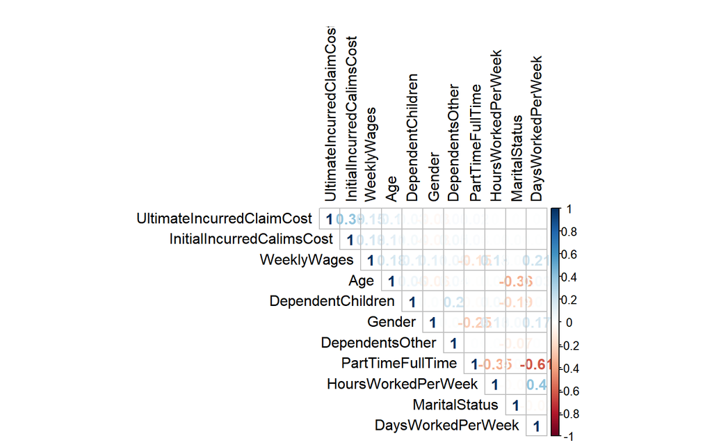

```r
claim %>%
  filter(!is.na(UltimateIncurredClaimCost), !is.na(MaritalStatus)) %>%
  select(Age:UltimateIncurredClaimCost, -ClaimDescription) %>%
  mutate(across(is.character, as.factor)) %>%
  mutate_if(is.factor, as.numeric) %>%
  cor %>%
  {.[order(abs(.[, "UltimateIncurredClaimCost"]), decreasing = TRUE),
     order(abs(.[, "UltimateIncurredClaimCost"]), decreasing = TRUE)]} %>%
  corrplot(method = "number", type = "upper",
           mar = c(0, 0, 1.5, 0), tl.col = "black")
```

$X$들 중에 $y$와 선형적인 상관성은 거의 미약하고, 초기 청구비용에 관한 변수(`IntiallncurredClaimCost`)만이 약간의 양의 상관을 보이고 있다고 할 수 있다. 아울러, 결혼 여부는 거의 선형적 관계가 아예 없어보인다. 그럼 우선 결혼 여부에 관한 변수에서 결측을 갖는 관측치의 경우 “알수없음(U)”으로 대치하고 모델링을 진행하자.

```r
claim_train2 <- claim_train %>%
  select(Age:UltimateIncurredClaimCost, -ClaimDescription) %>%
  mutate(MaritalStatus = factor(ifelse(is.na(MaritalStatus), "U", MaritalStatus)))
claim_test2 <- claim_test %>%
  select(Age:InitialIncurredCalimsCost, -ClaimDescription) %>%
  mutate(MaritalStatus = factor(ifelse(is.na(MaritalStatus), "U", MaritalStatus)))
```

## **3 Modelling**

먼저 {recipes}를 이용해 모형 적합 전 필요한 전처리를 수행한다. 혹시, {tidymodels} 패키지에 익숙하지 않다면, [여기](https://github.com/be-favorite/Tutorial_tidymodels)를 참고해주세요.

```r
cla_rec <- recipe(UltimateIncurredClaimCost ~ ., data = claim_train2) %>%
  step_normalize(all_predictors(), -all_nominal()) %>%
  step_dummy(all_nominal())
```

본 연구에서는 랜덤포레스트 모형을 적합해볼 것이며, 먼저 모수 튜닝을 위해 자료를 3-fold로 나눠줍니다.

```r
set.seed(1)
cla_vfold <- vfold_cv(claim_train2, v = 3, strata = UltimateIncurredClaimCost)
```

다음으로 튜닝을 위한 모형 객체를 준비할 것이며, 본 모형 적합에 조정할 초 모수는 랜덤포레스트의 모형 형성 시 매 트리 적합에 고려할 변수들의 개수를 조정하는 `mtry`입니다.

```r
rf_model <- rand_forest(mtry = tune()) %>%
  set_mode("regression") %>%
  set_engine("ranger")
```

```r
rf_model %>%
  parameters() %>%
  finalize(x = juice(prep(cla_rec)) %>% select(-UltimateIncurredClaimCost)) %>%
  pull("object")
```

```
## [[1]]
## # Randomly Selected Predictors (quantitative)
## Range: [1, 12]
```

다음으로 `workflow()`를 이용해 recipe 객체와 모형 객체를 결합해 줍니다.

```r
rf_wflow <- workflow() %>%
  add_model(rf_model) %>%
  add_recipe(cla_rec)
rf_wflow
```

```
## == Workflow ====================================================================
## Preprocessor: Recipe
## Model: rand_forest()
##
## -- Preprocessor ----------------------------------------------------------------
## 2 Recipe Steps
##
## * step_normalize()
## * step_dummy()
##
## -- Model -----------------------------------------------------------------------
## Random Forest Model Specification (regression)
##
## Main Arguments:
##   mtry = tune()
##
## Computational engine: ranger
```

다음으로는 `mtry`의 범위를 지정해줍니다. 본 모형 적합에서는 매 트리 적합시 최소 3개, 최대 10개의 변수를 고려해보려고 합니다.

```r
rf_param <- rf_wflow %>%
  parameters() %>%
  update(mtry = mtry(range = c(3L, 10L)))
rf_param %>% pull("object")
```

```
## [[1]]
## # Randomly Selected Predictors (quantitative)
## Range: [3, 10]
```

이정도 초모수 조합은 grid search로도 충분하므로, 해당 모수 조합의 grid를 만듭니다.

```r
rf_grid <- grid_regular(rf_param, levels = 8)
rf_grid
```

```
## # A tibble: 8 x 1
##    mtry
##   <int>
## 1     3
## 2     4
## 3     5
## 4     6
## 5     7
## 6     8
## 7     9
## 8    10
```

병렬 처리를 위한 설정을 해줍니다.

```r
library(doFuture)
all_cores <- parallel::detectCores(logical = FALSE) - 1
registerDoFuture()
cl <- parallel::makeCluster(all_cores)
plan(future::cluster, workers = cl)
```

이제 튜닝을 시작합니다.😊

```r
options(future.rng.onMisue = "ignore")
rf_search <- tune_grid(rf_wflow, grid = rf_grid, resamples = cla_vfold,
                       param_info = rf_param)
```

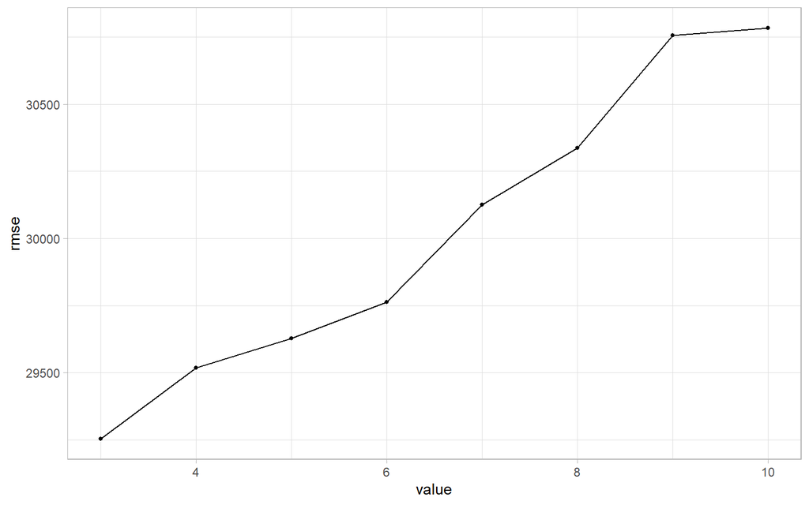

```r
autoplot(rf_search, metric = "rmse")
```

## **4 Prediction**

이제 최종 예측을 수행하고 글을 마무리 하겠습니다.

```r
rf_param_final <- select_best(rf_search, metric = "rmse")
rf_wflow_final <- finalize_workflow(rf_wflow, rf_param_final)
rf_wflow_final_fit <- fit(rf_wflow_final, data = claim_train2)
```

```r
cla_rec2 <- pull_workflow_prepped_recipe(rf_wflow_final_fit)
rf_final_fit <- pull_workflow_fit(rf_wflow_final_fit)

claim_test2$.pred <- predict(rf_final_fit,
                             new_data = bake(cla_rec2, claim_test2)) %>% pull(.pred)
```

```r
claim_test2 %>%
  mutate(ClaimNumber = claim_test %>% pull(ClaimNumber)) %>%
  select(ClaimNumber, .pred) %>%
  rename(UltimateIncurredClaimCost = .pred) %>%
  vroom_write("./submission/submission_1.csv", delim = ",")
```

분석을 러프하게 진행하고 마지막으로 예측 작업까지 해보았습니다. 아직 완성된 글이 아니니 조금만 기다려 주세요.😓 부지런히 업데이트 하겠습니다.